# High School Seniors t Test

```r
library(tidyverse)
library(DT)
library(pander)
library(readr)
library(ggplot2)
library(knitr)
library(kableExtra)

HSS <- read_csv("../../Data/HighSchoolSeniors.csv")
#Remember: select "Session, Set Working Directory, To Source File Location", and then play this R-chunk into your console to read the HSS data into R.

# View(HSS)
# names(HSS)

# cat("Test Statistic:", t_test_result$statistic, "\n")
# print(t_test_result)
```

## Sleep and Memory

We know that sleep effects memory, but how much? Performing an independent t test against students who got less than 8 hours of sleep per night, and students who got 8 or more, will we see a significant difference? We will set our alpha at .05 for this test. We also will remove several problematic data points, such as reports of over 44000 hours of sleep in one night (but wouldn’t that be nice!).

#### Null Hypothesis ($H_0$):

$$H_0: \mu_{\text{8 or more hours}} =
\mu_{\text{7 or fewer hours}}$$

#### Alternative Hypothesis ($H_a$):

$$H_a: \text{There is a significant
difference in the mean memory test scores between high school students
who get 8 or more hours of sleep per night and those who get less than 8
hours of sleep per night.}$$

$$H_a: \mu_{\text{8 or more hours}} \neq
\mu_{\text{7 or fewer hours}}$$

```r
HSS$Sleep_Hours_Schoolnight <- gsub("6hrs", "1", HSS$Sleep_Hours_Schoolnight)
HSS$Sleep_Hours_Schoolnight <- as.numeric(HSS$Sleep_Hours_Schoolnight)
HSS <- subset(HSS, !is.na(Sleep_Hours_Schoolnight) & Sleep_Hours_Schoolnight <= 20)


eight_or_more <- HSS[HSS$Sleep_Hours_Schoolnight >= 8, ]
less_than_eight <- HSS[HSS$Sleep_Hours_Schoolnight < 8, ]

# Perform independent samples t-test
pander(t_test_result <- t.test(
  eight_or_more$Score_in_memory_game,
  less_than_eight$Score_in_memory_game
))
```

Welch Two Sample t-test: `eight_or_more$Score_in_memory_game` and `less_than_eight$Score_in_memory_game`

| Test statistic | df | P value | Alternative hypothesis | mean of x | mean of y |
| --- | --- | --- | --- | --- | --- |
| -0.06666 | 112.2 | 0.947 | two.sided | 45.99 | 46.11 |

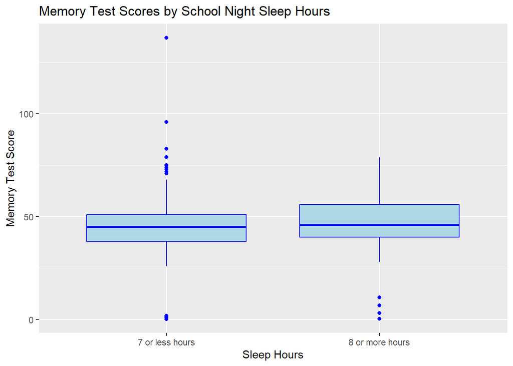

```r
boxplot_data <- data.frame(
  Group = rep(c("8 or more hours", "7 or less hours"),
              c(nrow(eight_or_more), nrow(less_than_eight))),
  Score_in_memory_game = c(eight_or_more$Score_in_memory_game,
                            less_than_eight$Score_in_memory_game)
)

# Create the boxplot
ggplot(boxplot_data, aes(x = Group, y = Score_in_memory_game)) +
  geom_boxplot(fill = "lightblue", color = "blue") +
  labs(title = "Memory Test Scores by School Night Sleep Hours",
       x = "Sleep Hours",
       y = "Memory Test Score")
```

Our p-value of 0.947 is not below our alpha of .05, so there is not enough evidence to support the hypothesis that the distributions of each are different. It would seem that losing an hour or two won’t make a significant difference in memory performance.

## Table

Here is a table showing the data:

```r
sleep_hours_counts <- table(HSS$Sleep_Hours_Schoolnight)

# Print the formatted table
kable(sleep_hours_counts, caption = "Sleep Hours Counts", col.names = c("Sleep Hours", "Count")) %>%
  kable_styling(full_width = FALSE)
```

Sleep Hours Counts

| Sleep Hours | Count |
| --- | --- |
| 0.46 | 2 |
| 0.5 | 2 |
| 1 | 1 |
| 2 | 2 |
| 3 | 5 |
| 4 | 14 |
| 4.5 | 1 |
| 5 | 50 |
| 5.5 | 2 |
| 6 | 116 |
| 6.5 | 9 |
| 7 | 126 |
| 7.5 | 10 |
| 8 | 66 |
| 8.5 | 2 |
| 9 | 9 |
| 9.5 | 1 |
| 10 | 2 |
| 11 | 1 |

## Conclusion

It seems like missing an hour or two of sleep really does not make a significant in memory performance according to this test.